# Pop Quiz

## 1. Install Packages

Install the following packages:

- dplyr
- ggplot

```r
library("dplyr")
library("ggplot2")
```

## 2. Read CSV

Read in the McDonalds nutritional data csv from `http://datasciencecsus.com/introToR/menu.csv`

```r
menu = read.csv(url("http://datasciencecsus.com/introToR/menu.csv"))
names(menu)
```

```
##  [1] "Category"                      "Item"
##  [3] "Serving.Size"                  "Calories"
##  [5] "Calories.from.Fat"             "Total.Fat"
##  [7] "Total.Fat....Daily.Value."     "Saturated.Fat"
##  [9] "Saturated.Fat....Daily.Value." "Trans.Fat"
## [11] "Cholesterol"                   "Cholesterol....Daily.Value."
## [13] "Sodium"                        "Sodium....Daily.Value."
## [15] "Carbohydrates"                 "Carbohydrates....Daily.Value."
## [17] "Dietary.Fiber"                 "Dietary.Fiber....Daily.Value."
## [19] "Sugars"                        "Protein"
## [21] "Vitamin.A....Daily.Value."     "Vitamin.C....Daily.Value."
## [23] "Calcium....Daily.Value."       "Iron....Daily.Value."
```

## 3. Make Sodium/Calorie Ratio Column

Make a new column in menu “sodpercal” that represents the ratio of Sodium to Calories in each item. (Sodium/Calories)

```r
menu = mutate(menu, sodpercal = Sodium/Calories);
```

## 4. Remove weird values

Uh oh! Not all of the items have calories, which is giving us values such as “INF” and “NaN” when we are dividing by zero.

Let’s filter out our menu dataframe to only contain the rows where the Calories column contains a positive integer.

```r
menu = filter(menu,  Calories != 0)
```

## 5. That’s mean.

Now that we have only numeric values in our sodpercal column, find the average value of this column and store it in a variable “spcAve”

```r
spcAve = mean(menu$sodpercal)
```

## 6. Let’s make a graph!

Make a graph with Calories on the X-axis and Sodium on the Y-axis

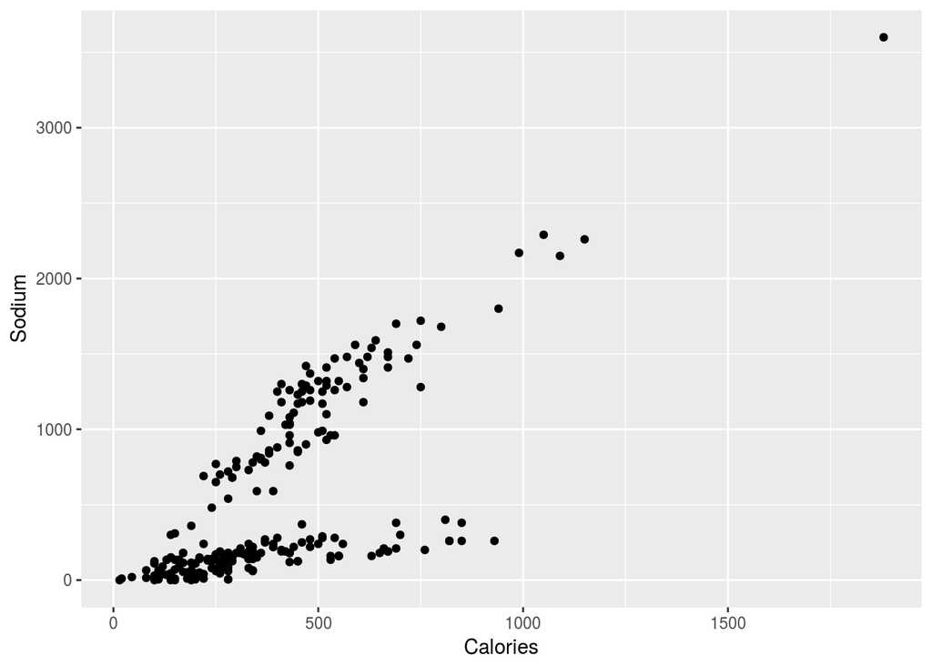

```r
ggplot(data=menu, aes(x=Calories)) +
  geom_point(aes(y=Sodium))
```

## 7. Add average line

Add a line on the graph showing the average Sodium/Calorie value. (hint: stat_function)

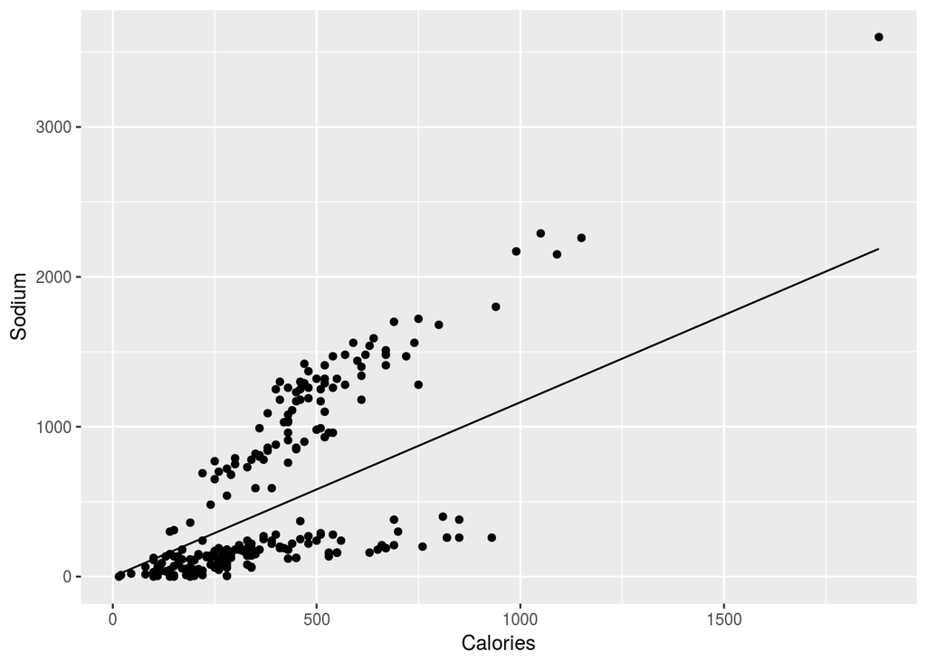

```r
ggplot(data=menu, aes(x=Calories)) +
  geom_point(aes(y=Sodium)) +
  stat_function(fun = function(x) { x * spcAve })
```

## 8. Let’s only look at those upper values

Our average line doesn’t really follow either of the two groups… Let’s only focus on that upper group.

Let’s just filter our menu to only contain values where the sodpercal is above the mean sodpercal.

```r
menu = filter(menu, menu$sodpercal > spcAve)
```

## 9. What are these Items?

Get the Item Names of the items remaining in the menu dataframe.

```r
menu$Item
```

```
##  [1] Egg McMuffin
##  [2] Egg White Delight
##  [3] Sausage McMuffin
##  [4] Sausage McMuffin with Egg
##  [5] Sausage McMuffin with Egg Whites
##  [6] Steak & Egg McMuffin
##  [7] Bacon, Egg & Cheese Biscuit (Regular Biscuit)
##  [8] Bacon, Egg & Cheese Biscuit (Large Biscuit)
##  [9] Bacon, Egg & Cheese Biscuit with Egg Whites (Regular Biscuit)
## [10] Bacon, Egg & Cheese Biscuit with Egg Whites (Large Biscuit)
## [11] Sausage Biscuit (Regular Biscuit)
## [12] Sausage Biscuit (Large Biscuit)
## [13] Sausage Biscuit with Egg (Regular Biscuit)
## [14] Sausage Biscuit with Egg (Large Biscuit)
## [15] Sausage Biscuit with Egg Whites (Regular Biscuit)
```

[output cut: 79 more lines]

## 10. Graph it again

Okay, now let’s graph these values one more time along with the new average.

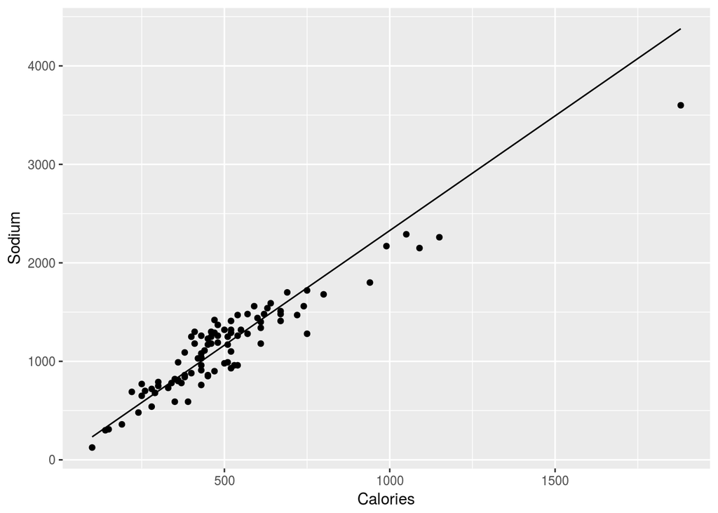

```r
ggplot(data=menu, aes(x=Calories)) +
  geom_point(aes(y=Sodium)) +
  stat_function(fun = function(x) { x * mean(menu$sodpercal) })
```